# Clean Demographic

Author

Yan Zhu

Published

June 6, 2024

## Introduction

In this file, I will clean and preprocess Demographic data from Baseline data of ESM study. The goal is to prepare the data for analysis.

**Note:** The data file is from the CSV file which generated from Data Anonymization.Rmd

Check and view all the variable of Demographic data.

## Set up

### load packages

[output not shown]

### read data

```r
# dis2, dis_inj, dis_combined, dis_mult, rel, smu (In old code book, but not in the data)
# ADD! I will create a new Code Book which could be found in repo/sample_code

demog <- read_csv("/Users/yan/Desktop/sample_code/ESM/1_anonymization/anonymous_baseline.csv", show_col_types = FALSE) %>%
  select(random_id, age, res, sch_yr, race, mult, race_txt, eth, dis1, dis_dev,
         dis_lrn, dis_sen, dis_mob, dis_psy, dis_unl, dis_txt, dis_ill,dis_dev,
         gend, trans, sx_ori,, dem12, f_aid, p_grnt, job, f_need, fgen) %>% glimpse()
```

```
Rows: 254
Columns: 26
$ random_id <dbl> 130598, 421317, 989682, 880440, 287165, 877047, 501614, 5827…
$ age       <dbl> 19, 19, 19, 18, 19, 18, 20, 18, 20, 20, 19, 18, 18, 18, 18, …
$ res       <dbl> 1, 1, 1, 1, 1, 1, 2, 1, 2, 4, 1, 1, 1, 1, 1, 1, 1, 1, 1, 2, …
$ sch_yr    <dbl> 1, 1, 1, 1, 1, 1, 2, 1, 2, 2, 2, 1, 1, 1, 1, 1, 1, 1, 1, 2, …
$ race      <chr> "White", "White", "White", "White", "White", "Black or Afric…
$ mult      <chr> NA, NA, NA, NA, NA, NA, NA, NA, NA, NA, NA, NA, NA, NA, NA, …
$ race_txt  <chr> NA, NA, NA, NA, NA, NA, NA, NA, NA, NA, NA, NA, "Middle East…
$ eth       <dbl> 0, 0, 0, 0, 0, 0, 0, 0, 0, 0, 0, 0, 0, 1, 0, 0, 0, 0, 0, 0, …
$ dis1      <dbl> 0, 0, 1, 0, 0, 1, 0, 0, 0, 0, 0, 0, 1, 0, 0, 0, 0, 0, 0, 0, …
$ dis_dev   <dbl> NA, NA, 1, NA, NA, 0, NA, NA, NA, NA, NA, NA, 0, NA, NA, NA,…
$ dis_lrn   <dbl> NA, NA, 1, NA, NA, 0, NA, NA, NA, NA, NA, NA, 0, NA, NA, NA,…
$ dis_sen   <dbl> NA, NA, 0, NA, NA, 0, NA, NA, NA, NA, NA, NA, 0, NA, NA, NA,…
$ dis_mob   <dbl> NA, NA, 0, NA, NA, 0, NA, NA, NA, NA, NA, NA, 0, NA, NA, NA,…
$ dis_psy   <dbl> NA, NA, 0, NA, NA, 1, NA, NA, NA, NA, NA, NA, 1, NA, NA, NA,…
$ dis_unl   <dbl> NA, NA, 0, NA, NA, 0, NA, NA, NA, NA, NA, NA, 1, NA, NA, NA,…
$ dis_txt   <chr> NA, NA, NA, NA, NA, NA, NA, NA, NA, NA, NA, NA, "Epilepsy", …
$ dis_ill   <dbl> NA, NA, 0, NA, NA, 0, NA, NA, NA, NA, NA, NA, 1, NA, NA, NA,…
$ gend      <dbl> 2, 2, 1, 2, 1, 1, 2, 1, 2, 2, 2, 2, 1, 2, 1, 1, 2, 2, 2, 2, …
$ trans     <dbl> 0, 0, 0, 0, 0, 0, 0, 0, 0, 0, 0, 0, 0, 0, 0, 0, 0, 0, 0, 0, …
$ sx_ori    <dbl> 5, 5, 5, 3, 5, 5, 5, 5, 5, 5, 5, 5, 4, 5, 5, 1, 5, 5, 4, 5, …
$ dem12     <dbl> 2, 49, 5, 1, 145, 7, 45, 4, 345, 34, 45, 49, 8, 34, 24, 45, …
$ f_aid     <dbl> 0, 0, 0, 0, 1, 1, 0, 0, 0, 0, 1, 1, 0, 0, 1, 1, 0, 1, 0, 1, …
$ p_grnt    <dbl> 0, 0, 0, 0, 1, 1, 0, 0, 0, 0, 0, 1, 0, 0, 1, 1, 0, 1, 0, 1, …
$ job       <dbl> 0, 1, 0, 0, 0, 1, 0, 0, 1, 1, 1, 0, 1, 0, 0, 1, 0, 1, 0, 0, …
$ f_need    <dbl> 3, 1, 1, 1, 1, 1, 2, 4, 1, 1, 2, 2, 3, 2, 3, 2, 1, 3, 4, 2, …
$ fgen      <dbl> 0, 0, 0, 0, 1, 0, 0, 0, 0, 0, 0, 0, 0, 0, 1, 1, 0, 0, 0, 0, …
```

## Variable Check

### Age

Variable code as “age” Survey Question: “How old are you?”

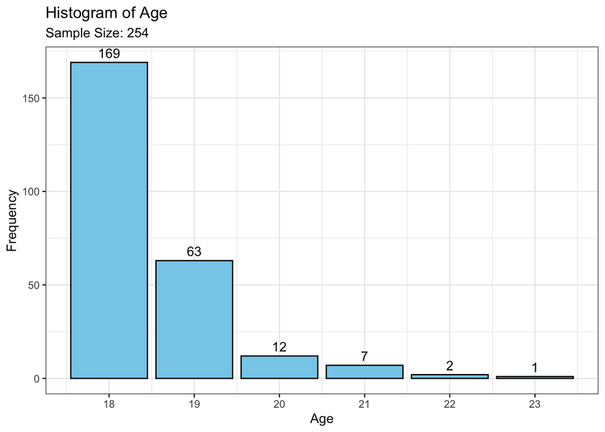

```r
ggplot(demog, aes(x = age)) +
  geom_bar(fill = "skyblue", color = "black") +
  geom_text(stat = "count", aes(label = after_stat(count)), vjust = -0.5) +
  scale_x_continuous(breaks = seq(min(demog$age), max(demog$age), by = 1)) +
  labs(x = "Age",
       y = "Frequency",
       title = "Histogram of Age",
       subtitle = paste("Sample Size:", nrow(demog))) +
  theme(plot.subtitle = element_text(size = 10)) +
  theme_bw()
```

### Residence

Variable code as “res” Where do you currently live?

```r
table(demog$res)
```

```
  1   2   4   5   6   8
196  20  28   7   2   1
```

**Note:** 1 = On campus in a dorm , 2 = On campus in an apartment, 3 = Other on campus arrangement, 4 = Off campus apartment, 5 = Off campus house, 6 = Off campus with parents, 7 = On campus fraternity/soroity house, 8 = Off campus fraternity/sorority house, 9 = Other

```r
demog$res <- ifelse(demog$res == 1, "On campus in a dorm", demog$res)
demog$res <- ifelse(demog$res == 2, "On campus in an apartment", demog$res)
demog$res <- ifelse(demog$res == 4, "Off campus apartment", demog$res)
demog$res <- ifelse(demog$res == 5, "Off campus with parents", demog$res)
demog$res <- ifelse(demog$res == 6, "Off campus with parents", demog$res)
demog$res <- ifelse(demog$res == 8, "Off campus fraternity/sorority house", demog$res)
prop_tab(demog, res)
```

```
# A tibble: 5 × 3
  res                                      n    prop
  <chr>                                <int>   <dbl>
1 Off campus apartment                    28 0.110
2 Off campus fraternity/sorority house     1 0.00394
3 Off campus with parents                  9 0.0354
4 On campus in a dorm                    196 0.772
5 On campus in an apartment               20 0.0787
```

### School Tear

Variable code as “sch_yr” What is your year in school?

```r
prop_tab(demog, sch_yr)
```

```
# A tibble: 4 × 3
  sch_yr     n    prop
   <dbl> <int>   <dbl>
1      1   213 0.839
2      2    32 0.126
3      3     7 0.0276
4      4     2 0.00787
```

### Race

Variable code as “race” Recognizing that race is complex, which of the following classifications of race best describe how you identify?

```r
# Checking NA
sum(is.na(demog$race))
```

```
[1] 2
```

Most of the variables having NA values is reasonable because there were no applicable options to describe our participants. However, Race has 2 missing data points which seem unexpected if “mult” and “race_txt” are also NA because they are open text-entry responses. Let’s check those two rows.

```r
# check the rows with NA in Race
demog[is.na(demog$race), ]
```

```
# A tibble: 2 × 26
  random_id   age res    sch_yr race  mult  race_txt   eth  dis1 dis_dev dis_lrn
      <dbl> <dbl> <chr>   <dbl> <chr> <chr> <chr>    <dbl> <dbl>   <dbl>   <dbl>
1    374100    18 Off c…      1 <NA>  <NA>  <NA>         0     0      NA      NA
2    307768    18 On ca…      1 <NA>  <NA>  <NA>         0     0      NA      NA
# ℹ 15 more variables: dis_sen <dbl>, dis_mob <dbl>, dis_psy <dbl>,
#   dis_unl <dbl>, dis_txt <chr>, dis_ill <dbl>, gend <dbl>, trans <dbl>,
#   sx_ori <dbl>, dem12 <dbl>, f_aid <dbl>, p_grnt <dbl>, job <dbl>,
#   f_need <dbl>, fgen <dbl>
```

*There were no information in race_txt and mult(Open text-entry responses from individuals identifying as multiracial). I would label it with “Unknown” string*

```r
# Change NA to string.
demog$race <- ifelse(is.na(demog$race), "Unknown", demog$race)
prop_tab(demog, race)
```

```
# A tibble: 8 × 3
  race                          n    prop
  <chr>                     <int>   <dbl>
1 Asian or Asian American      40 0.157
2 Black or African American     6 0.0236
3 Hawiian/Pacific Islander      1 0.00394
4 Multiracial                   6 0.0236
5 Native American               1 0.00394
6 Text-entry                    2 0.00787
7 Unknown                       2 0.00787
8 White                       196 0.772
```

More data cleaning on race! Text-entry is also an unexpected answer.

```r
# make sure if "Text-entry" with other information about race in other columns
demog[demog$race == "Text-entry", ]
```

```
# A tibble: 2 × 26
  random_id   age res    sch_yr race  mult  race_txt   eth  dis1 dis_dev dis_lrn
      <dbl> <dbl> <chr>   <dbl> <chr> <chr> <chr>    <dbl> <dbl>   <dbl>   <dbl>
1    635277    18 On ca…      1 Text… <NA>  <NA>         0     0      NA      NA
2    163646    18 On ca…      1 Text… <NA>  <NA>         1     0      NA      NA
# ℹ 15 more variables: dis_sen <dbl>, dis_mob <dbl>, dis_psy <dbl>,
#   dis_unl <dbl>, dis_txt <chr>, dis_ill <dbl>, gend <dbl>, trans <dbl>,
#   sx_ori <dbl>, dem12 <dbl>, f_aid <dbl>, p_grnt <dbl>, job <dbl>,
#   f_need <dbl>, fgen <dbl>
```

*Nope, I will replace “Unknown” instead of “Text-entry”*

```r
demog$race <- ifelse(demog$race == "Text-entry", "Unknown", demog$race)
prop_tab(demog, race)
```

```
# A tibble: 7 × 3
  race                          n    prop
  <chr>                     <int>   <dbl>
1 Asian or Asian American      40 0.157
2 Black or African American     6 0.0236
3 Hawiian/Pacific Islander      1 0.00394
4 Multiracial                   6 0.0236
5 Native American               1 0.00394
6 Unknown                       4 0.0157
7 White                       196 0.772
```

```r
demog[!is.na(demog$race_txt), ]
```

```
# A tibble: 4 × 26
  random_id   age res    sch_yr race  mult  race_txt   eth  dis1 dis_dev dis_lrn
      <dbl> <dbl> <chr>   <dbl> <chr> <chr> <chr>    <dbl> <dbl>   <dbl>   <dbl>
1    442681    18 On ca…      1 White <NA>  Middle …     0     1       0       0
2    984636    18 On ca…      1 Asia… <NA>  Latino       1     0      NA      NA
3    325737    19 On ca…      1 White <NA>  Jewish       0     1       1       1
4    970489    19 On ca…      1 White <NA>  Hispani…     1     0      NA      NA
# ℹ 15 more variables: dis_sen <dbl>, dis_mob <dbl>, dis_psy <dbl>,
#   dis_unl <dbl>, dis_txt <chr>, dis_ill <dbl>, gend <dbl>, trans <dbl>,
#   sx_ori <dbl>, dem12 <dbl>, f_aid <dbl>, p_grnt <dbl>, job <dbl>,
#   f_need <dbl>, fgen <dbl>
```

```r
demog[!is.na(demog$mult), ]
```

```
# A tibble: 5 × 26
  random_id   age res    sch_yr race  mult  race_txt   eth  dis1 dis_dev dis_lrn
      <dbl> <dbl> <chr>   <dbl> <chr> <chr> <chr>    <dbl> <dbl>   <dbl>   <dbl>
1    872951    18 On ca…      1 White hisp… <NA>         1     0      NA      NA
2    967552    18 Off c…      1 White Leba… <NA>         0     0      NA      NA
3    282167    18 On ca…      1 White Whit… <NA>         0     0      NA      NA
4    660729    18 On ca…      1 White Whit… <NA>         0     0      NA      NA
5    503542    19 On ca…      1 Asia… Whit… <NA>         1     0      NA      NA
# ℹ 15 more variables: dis_sen <dbl>, dis_mob <dbl>, dis_psy <dbl>,
#   dis_unl <dbl>, dis_txt <chr>, dis_ill <dbl>, gend <dbl>, trans <dbl>,
#   sx_ori <dbl>, dem12 <dbl>, f_aid <dbl>, p_grnt <dbl>, job <dbl>,
#   f_need <dbl>, fgen <dbl>
```

### Ethnicity

Do you identify as Hispanic or Latino/Latina or Latinx?

```r
prop_tab(demog, eth)
```

```
# A tibble: 2 × 3
    eth     n  prop
  <dbl> <int> <dbl>
1     0   228 0.898
2     1    26 0.102
```

```r
# 1 = Yes, 0 = No, 3 = prefer not to respond
```

### Disability

Do you consider yourself to have a disability or be disabled? (e.g., intellectual disability, learning disability, sensory disability, mobility disability, mental illness, etc.)

```r
prop_tab(demog, dis1)
```

```
# A tibble: 2 × 3
   dis1     n  prop
  <dbl> <int> <dbl>
1     0   221 0.870
2     1    33 0.130
```

```r
prop_tab(demog, dis_dev)
```

```
# A tibble: 3 × 3
  dis_dev     n   prop
    <dbl> <int>  <dbl>
1       0    21 0.0827
2       1    14 0.0551
3      NA   219 0.862
```

```r
# Select columns containing "dis_" in their column names
dis_columns <- demog %>%
  select(contains("dis_"))

# Count the number of NAs in each column
na_counts <- colSums(is.na(dis_columns))
na_counts
```

```
dis_dev dis_lrn dis_sen dis_mob dis_psy dis_unl dis_txt dis_ill
    219     219     219     219     219     221     249     221
```

Except “dis_txt”, the count the number of columns which containing “dis_” should be 221. However, the NA count here seems not right.

```r
# List the column names that need to be replaced
cols_to_replace <- c("dis_dev", "dis_lrn", "dis_sen", "dis_mob", "dis_psy", "dis_unl", "dis_ill")

# Use mutate and across to replace
demog <- demog %>%
  mutate(across(all_of(cols_to_replace), ~ifelse(is.na(.), 0, .)))

demog <- demog %>%
  mutate(dis_txt = ifelse(is.na(dis_txt), "None", dis_txt))
```

### Gender

Recognizing that gender is complex, how would you describe your gender?

```r
# 1 = Man, 2 = Woman, 3 = Non-binary, 4 = Gender fluid, 5 = Two-Spirit, 6 = Agender, 7 = Pangender, 8 = Another gender identity [Write in]
prop_tab(demog, gend)
```

```
# A tibble: 4 × 3
   gend     n    prop
  <dbl> <int>   <dbl>
1     1    85 0.335
2     2   164 0.646
3     4     4 0.0157
4     5     1 0.00394
```

```r
demog$gend <- ifelse(demog$gend == 1, "Male", demog$gend)
demog$gend <- ifelse(demog$gend == 2, "Female", demog$gend)
demog$gend <- ifelse(demog$gend == 4, "Other", demog$gend)
demog$gend <- ifelse(demog$gend == 5, "Other", demog$gend)
prop_tab(demog, gend)
```

```
# A tibble: 3 × 3
  gend       n   prop
  <chr>  <int>  <dbl>
1 Female   164 0.646
2 Male      85 0.335
3 Other      5 0.0197
```

Question: Are you transgender?

```r
# 1 = Yes, 0 = No
prop_tab(demog, trans)
```

```
# A tibble: 2 × 3
  trans     n    prop
  <dbl> <int>   <dbl>
1     0   253 0.996
2     1     1 0.00394
```

Question: Recognizing that sexual orientation can be fluid, how would you describe your current sexual orientation?

```r
prop_tab(demog, sx_ori)
```

```
# A tibble: 6 × 3
  sx_ori     n    prop
   <dbl> <int>   <dbl>
1      1     5 0.0197
2      2     2 0.00787
3      3    17 0.0669
4      4     6 0.0236
5      5   219 0.862
6      6     5 0.0197
```

```r
# 1 = Gay, 2 = Lesbian, 3 = Bisexual, 4 = Pansexual, 5 = Heterosexual/Straight, 6 = Other [Write in]
demog$sx_ori <- recode(demog$sx_ori,
                       `1` = "Gay",
                       `2` = "Lesbian",
                       `3` = "Bisexual",
                       `4` = "Pansexual",
                       `5` = "Heterosexual",
                       `6` = "Other")

prop_tab(demog, sx_ori)
```

```
# A tibble: 6 × 3
  sx_ori           n    prop
  <chr>        <int>   <dbl>
1 Bisexual        17 0.0669
2 Gay              5 0.0197
3 Heterosexual   219 0.862
4 Lesbian          2 0.00787
5 Other            5 0.0197
6 Pansexual        6 0.0236
```

```r
glimpse(demog$dem12)
```

```
 num [1:254] 2 49 5 1 145 7 45 4 345 34 ...
```

Question: Do you participate in any of the following activities (check all that apply):

```r
# These question is a multiple choice question, and each number represent an activity option.
## Select all that apply: 1=Athletics; 2=Club sports; 3=Greek life; 4=Registered student organizations; 5=Volunteer work; 6=Associated students of Madison; 7=Work-study; 8=Research Involvement; 9=Religious-affiliated student organizations
demog$dem12 <- sapply(strsplit(as.character(demog$dem12), ""), function(x) paste(x, collapse = ","))
glimpse(demog$dem12)
```

```
 chr [1:254] "2" "4,9" "5" "1" "1,4,5" "7" "4,5" "4" "3,4,5" "3,4" "4,5" ...
```

Count number of acvitity were select in question dem12.

```r
demog$num_activity <- str_count(demog$dem12, "\\d+")
range(demog$num_activity)
```

```
[1] 0 5
```

Do you receive financial aid?

```r
# 1 = Yes, 0 = No
prop_tab(demog, f_aid)
```

```
# A tibble: 2 × 3
  f_aid     n  prop
  <dbl> <int> <dbl>
1     0   157 0.618
2     1    97 0.382
```

Have you ever received a Pell grant?

```r
# 1 = Yes, 0 = No
prop_tab(demog, p_grnt)
```

```
# A tibble: 2 × 3
  p_grnt     n  prop
   <dbl> <int> <dbl>
1      0   202 0.795
2      1    52 0.205
```

Do you work for pay during the school year?

```r
# 1 = Yes, 0 = No
prop_tab(demog, job)
```

```
# A tibble: 2 × 3
    job     n  prop
  <dbl> <int> <dbl>
1     0   181 0.713
2     1    73 0.287
```

Since you have been a student at UW-Madison, how often have you had difficulty paying for basic necessities like food, clothing, or rent?

```r
# 1 = Never, 2 = Rarely, 3 = Sometimes, 4 = Often, 5 = All the time
prop_tab(demog,f_need)
```

```
# A tibble: 5 × 3
  f_need     n   prop
   <dbl> <int>  <dbl>
1      1   146 0.575
2      2    59 0.232
3      3    34 0.134
4      4    12 0.0472
5      5     3 0.0118
```

Would you consider yourself a first-gen college student (meaning your parents never completed a 4-year college or university degree)?

```r
# 1 = Yes, 0 = No, 3 = Not sure
prop_tab(demog, fgen)
```

```
# A tibble: 3 × 3
   fgen     n    prop
  <dbl> <int>   <dbl>
1     0   206 0.811
2     1    47 0.185
3     3     1 0.00394
```

```r
demog <- demog %>% select(random_id, age, res, sch_yr, race,
                          mult, race_txt, eth, dis1, dis_dev,
                          dis_lrn, dis_sen, dis_mob, dis_psy, dis_unl,
                          dis_txt, dis_ill, gend, trans, sx_ori,
                          dem12, num_activity, everything())
glimpse(demog)
```

```
Rows: 254
Columns: 27
$ random_id    <dbl> 130598, 421317, 989682, 880440, 287165, 877047, 501614, 5…
$ age          <dbl> 19, 19, 19, 18, 19, 18, 20, 18, 20, 20, 19, 18, 18, 18, 1…
$ res          <chr> "On campus in a dorm", "On campus in a dorm", "On campus …
$ sch_yr       <dbl> 1, 1, 1, 1, 1, 1, 2, 1, 2, 2, 2, 1, 1, 1, 1, 1, 1, 1, 1, …
$ race         <chr> "White", "White", "White", "White", "White", "Black or Af…
$ mult         <chr> NA, NA, NA, NA, NA, NA, NA, NA, NA, NA, NA, NA, NA, NA, N…
$ race_txt     <chr> NA, NA, NA, NA, NA, NA, NA, NA, NA, NA, NA, NA, "Middle E…
$ eth          <dbl> 0, 0, 0, 0, 0, 0, 0, 0, 0, 0, 0, 0, 0, 1, 0, 0, 0, 0, 0, …
$ dis1         <dbl> 0, 0, 1, 0, 0, 1, 0, 0, 0, 0, 0, 0, 1, 0, 0, 0, 0, 0, 0, …
$ dis_dev      <dbl> 0, 0, 1, 0, 0, 0, 0, 0, 0, 0, 0, 0, 0, 0, 0, 0, 0, 0, 0, …
$ dis_lrn      <dbl> 0, 0, 1, 0, 0, 0, 0, 0, 0, 0, 0, 0, 0, 0, 0, 0, 0, 0, 0, …
$ dis_sen      <dbl> 0, 0, 0, 0, 0, 0, 0, 0, 0, 0, 0, 0, 0, 0, 0, 0, 0, 0, 0, …
$ dis_mob      <dbl> 0, 0, 0, 0, 0, 0, 0, 0, 0, 0, 0, 0, 0, 0, 0, 0, 0, 0, 0, …
$ dis_psy      <dbl> 0, 0, 0, 0, 0, 1, 0, 0, 0, 0, 0, 0, 1, 0, 0, 0, 0, 0, 0, …
$ dis_unl      <dbl> 0, 0, 0, 0, 0, 0, 0, 0, 0, 0, 0, 0, 1, 0, 0, 0, 0, 0, 0, …
$ dis_txt      <chr> "None", "None", "None", "None", "None", "None", "None", "…
$ dis_ill      <dbl> 0, 0, 0, 0, 0, 0, 0, 0, 0, 0, 0, 0, 1, 0, 0, 0, 0, 0, 0, …
$ gend         <chr> "Female", "Female", "Male", "Female", "Male", "Male", "Fe…
$ trans        <dbl> 0, 0, 0, 0, 0, 0, 0, 0, 0, 0, 0, 0, 0, 0, 0, 0, 0, 0, 0, …
$ sx_ori       <chr> "Heterosexual", "Heterosexual", "Heterosexual", "Bisexual…
$ dem12        <chr> "2", "4,9", "5", "1", "1,4,5", "7", "4,5", "4", "3,4,5", …
$ num_activity <int> 1, 2, 1, 1, 3, 1, 2, 1, 3, 2, 2, 2, 1, 2, 2, 2, 0, 1, 0, …
$ f_aid        <dbl> 0, 0, 0, 0, 1, 1, 0, 0, 0, 0, 1, 1, 0, 0, 1, 1, 0, 1, 0, …
$ p_grnt       <dbl> 0, 0, 0, 0, 1, 1, 0, 0, 0, 0, 0, 1, 0, 0, 1, 1, 0, 1, 0, …
$ job          <dbl> 0, 1, 0, 0, 0, 1, 0, 0, 1, 1, 1, 0, 1, 0, 0, 1, 0, 1, 0, …
$ f_need       <dbl> 3, 1, 1, 1, 1, 1, 2, 4, 1, 1, 2, 2, 3, 2, 3, 2, 1, 3, 4, …
$ fgen         <dbl> 0, 0, 0, 0, 1, 0, 0, 0, 0, 0, 0, 0, 0, 0, 1, 1, 0, 0, 0, …
```

## Write CSV

```r
write.csv(demog, "/Users/yan/Desktop/sample_code/ESM/2_demograpgic/demog_data.csv", row.names = FALSE)
```